# Analysis of Hoovers Customer Data

Nathaniel Reed

January 13, 2016

# Part 1: Prepare Data

Customer sales data (“Account Data”) was split into 11 files, which were used to build customer lists. These files will be merged with the original customer data below:

## 1.1 Load Customer Lists

```r
customers <- data.frame()

for (i in 1:11) {
  filename <- paste(c("customers"),as.character(c(i)), ".csv", collapse="", sep="")
  customers_i <- read.csv(filename, stringsAsFactors=FALSE)
  customers <- rbind(customers, customers_i)
}
```

## 1.2 Convert variable types:

```r
# Make relevant variables factors
customers[,c("Primary.City")] <- as.factor(customers[,c("Primary.City")])
customers[,c("Primary.Zip")] <- as.factor(customers[,c("Primary.Zip")])
customers[,c("Primary.Country")] <- as.factor(customers[,c("Primary.Country")])
customers[,c("Line.Of.Business")] <- as.factor(customers[,c("Line.Of.Business")])
customers[,c("Owns.Rents")] <- as.factor(customers[,c("Owns.Rents")])
customers[,c("Is.Importer")] <- as.factor(customers[,c("Is.Importer")])
customers[,c("Is.Exporter")] <- as.factor(customers[,c("Is.Exporter")])
customers[,c("Company.Type")] <- as.factor(customers[,c("Company.Type")])
customers[,c("Is.Subsidiary")] <- as.factor(customers[,c("Is.Subsidiary")])
customers[,c("Location.Type")] <- as.factor(customers[,c("Location.Type")])
customers[,c("Exchange")] <- as.factor(customers[,c("Exchange")])
customers[,c("Is.Manufacturing")] <- as.factor(customers[,c("Is.Manufacturing")])
customers[,c("Is.Women.Owned")] <- as.factor(customers[,c("Is.Women.Owned")])
customers[,c("Is.Minority.Owned")] <- as.factor(customers[,c("Is.Minority.Owned")])
customers[,c("D.B.Prescreen.Score")] <- as.factor(customers[,c("D.B.Prescreen.Score")])
customers[,c("Primary.Industry")] <- as.factor(customers[,c("Primary.Industry")])
customers[,c("Primary.US.SIC.Code")] <- as.factor(customers[,c("Primary.US.SIC.Code")])
customers[,c("Primary.US.NAICS.Code")] <- as.factor(customers[,c("Primary.US.NAICS.Code")])
customers[,c("Postal.Delivery.Point")] <- as.factor(customers[,c("Postal.Delivery.Point")])

# Should be numeric, not character
customers[,c("Revenue.Growth....")] <- as.numeric(customers[,c("Revenue.Growth....")])
customers[,c("Income.Growth....")] <- as.numeric(customers[,c("Income.Growth....")])
```

## 1.3 Merge with Accounts

Merge with account data and convert sales variables to numeric type:

```r
accounts <- read.csv("customers.csv")
accounts[,c("Sales2013")] <- as.numeric(sub(",","", (sub("\\$","", accounts$Sales2013))))
accounts[,c("Sales2014")] <- as.numeric(sub(",","", (sub("\\$","", accounts$Sales2014))))
customer_accounts <- merge(accounts, customers, by.x = "DUNS", by.y = "D.U.N.S.Number")
```

## 1.4 Replace Missing Values

For sales figures, we replace missing values with zeroes:

```r
library(dplyr)
customer_accounts <- customer_accounts %>% mutate(Sales2013 = ifelse(is.na(Sales2013), 0, Sales2013))
customer_accounts <- customer_accounts %>% mutate(Sales2014 = ifelse(is.na(Sales2014), 0, Sales2014))
```

## 1.5 Remove extraneous variables

Many of these variables would not be useful as predictors (Duns #’s, street address, etc). To simplify our model, we’ll select variables we’re interested in and rename them for brevity. Also, we combine sales for 2013 to 2014 so we have one response variable to consider (combined_sales):

```r
customer_accounts <- dplyr::select(customer_accounts,
                                   sales2013=Sales2013,
                                   sales2014=Sales2014,
                                   total_assets=Total.Assets..US.Dollars..million.,
                                   market_value=Market.Value..US.Dollars..million.,
                                   total_empl=Total.Employees,
                                   empl_growth=Employee.Growth....,
                                   primary_sic=Primary.US.SIC.Code,
                                   primary_industry=Primary.Industry,
                                   primary_city=Primary.City,
                                   revenue_growth=Revenue.Growth....,
                                   revenue=Revenue..US.Dollars..million.,
                                   net_income=Net.Income..US.Dollars..million.,
                                   income_growth=Income.Growth....,
                                   is_manufacturing=Is.Manufacturing,
                                   is_women_owned=Is.Women.Owned,
                                   is_minority_owned=Is.Minority.Owned,
                                   db_pre_screen=D.B.Prescreen.Score,
                                   line_of_business=Line.Of.Business,
                                   owns_rents=Owns.Rents,
                                   is_importer=Is.Importer,
                                   is_exporter=Is.Exporter,
                                   company_type=Company.Type,
                                   is_subsidiary=Is.Subsidiary,
                                   location_type=Location.Type,
                                   employees_at_this_location=Employees.At.This.Location) %>%
  mutate(combined_sales=sales2013+sales2014)
```

# Part 2: Exploratory Analysis

## 2.1: Summary of data

```r
summary(customer_accounts)
```

```
##    sales2013        sales2014       total_assets      market_value
##  Min.   :     0   Min.   :     0   Min.   :      0   Min.   :     0.0
##  1st Qu.:     0   1st Qu.:     0   1st Qu.:      0   1st Qu.:   180.5
##  Median :  2500   Median :  2400   Median :      0   Median :   962.0
##  Mean   :  9912   Mean   :  9731   Mean   :   1085   Mean   :  8207.7
##  3rd Qu.:  6979   3rd Qu.:  6800   3rd Qu.:      0   3rd Qu.:  4218.7
##  Max.   :954798   Max.   :972654   Max.   :4497774   Max.   :549337.4
##                                    NA's   :5569      NA's   :42105
##    total_empl       empl_growth       primary_sic
##  Min.   :      1   Min.   :-99.84   87480000:  546
##  1st Qu.:     17   1st Qu.: -2.06   87420000:  507
##  Median :     65   Median :  2.90   60220000:  466
##  Mean   :   1238   Mean   :  8.49   60210000:  345
##  3rd Qu.:    250   3rd Qu.: 10.58   73790200:  344
##  Max.   :2200000   Max.   :984.62   (Other) :41582
##  NA's   :3878      NA's   :42347    NA's    :    6
##                          primary_industry     primary_city
##  Wholesale Sector                : 2072   New York  : 1378
##  Consulting Services             : 1721   Houston   :  908
##  Information Technology Services : 1559   Chicago   :  639
##  Banks & Credit Unions           : 1400   Atlanta   :  432
##  Business Services Sector        :  989   Washington:  383
##  Industrial Equipment Wholesalers:  948   Dallas    :  382
##  (Other)                         :35107   (Other)   :39674
##  revenue_growth      revenue           net_income       income_growth
##  Min.   :-99.89   Min.   :  -115.0   Min.   :-7224.20   Min.   :-99.10
##  1st Qu.: -1.65   1st Qu.:     3.3   1st Qu.:    0.00   1st Qu.:-17.63
##  Median :  4.99   Median :    16.2   Median :    0.00   Median :  6.37
##  Mean   : 10.18   Mean   :   458.2   Mean   :   23.19   Mean   : 28.03
##  3rd Qu.: 13.96   3rd Qu.:    69.5   3rd Qu.:    0.00   3rd Qu.: 33.40
##  Max.   :460.67   Max.   :485651.0   Max.   :53394.00   Max.   :979.46
##  NA's   :41781    NA's   :5569       NA's   :5569       NA's   :42593
##  is_manufacturing is_women_owned is_minority_owned     db_pre_screen
##  No :30370        No :40922      No :41885                    :  619
##  Yes:13426        Yes: 2874      Yes: 1911         High Risk  : 3505
##                                                    Low Risk   :36981
##                                                    Medium Risk: 2691
##
##
##
```

[output cut: 9 more lines]

```
##  No :28866   No :34692                      :36844   false:33627
##  Yes:14930   Yes: 9104   PRIVATE            : 3053   true :10169
##                          PUBLIC             : 1694
##                          SUBSIDIARY         : 1317
##                          PRIVATE_NON_PROFIT :  210
##                          PRIVATE_PARTNERSHIP:  183
##                          (Other)            :  495
##          location_type   employees_at_this_location combined_sales
##                 :    5   Min.   :    1.0            Min.   :      0
##  BRANCH         : 3204   1st Qu.:   13.0            1st Qu.:   1300
##  HEADQUARTERS   :21381   Median :   40.0            Median :   4944
##  SINGLE_LOCATION:19206   Mean   :  143.5            Mean   :  19644
##                          3rd Qu.:  110.0            3rd Qu.:  13731
##                          Max.   :65000.0            Max.   :1907948
##                          NA's   :1088
```

## 2.2: Table plot

A potentially useful visualization is the table plot, which divides the rows of data into bins and sorts the rows based on a single variable. We can sort the data on combined_sales to see if any relationships are apparent. Due to limitations on rendering the data, I omitted variables with high cardinality and limited the number of variables:

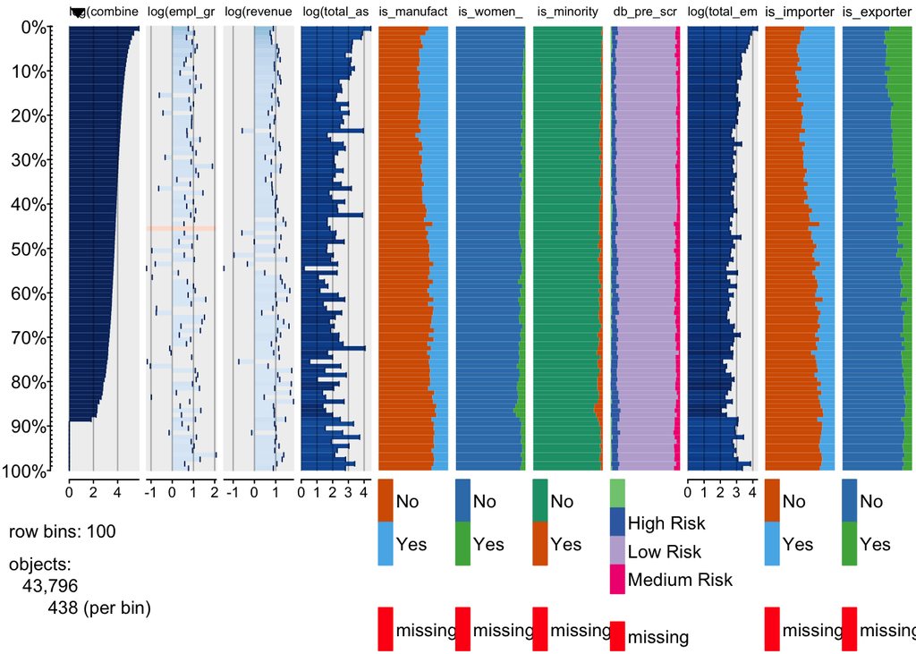

```r
require(tabplot)
tableplot(customer_accounts, select=c(combined_sales, empl_growth, revenue_growth, total_assets, is_manufacturing, is_women_owned, is_minority_owned, db_pre_screen, total_empl, is_importer, is_exporter), sortCol=combined_sales)
```

## 2.3: Financial predictors

What are the relationships between financial metrics like market value, net income, revenue and sales?

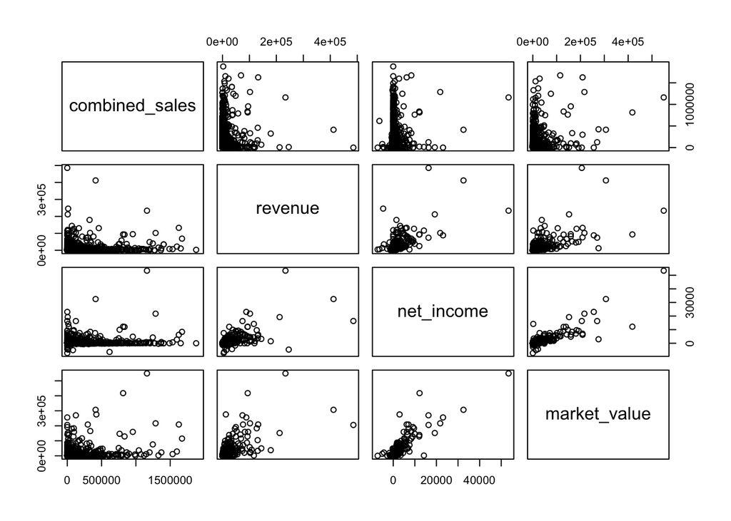

```r
pairs(~combined_sales + revenue + net_income + market_value, data=customer_accounts)
```

Among the scatterplots above, we find what looks like an interesting relationship between market value and sales. We can plot these and fit a regression line through the points:

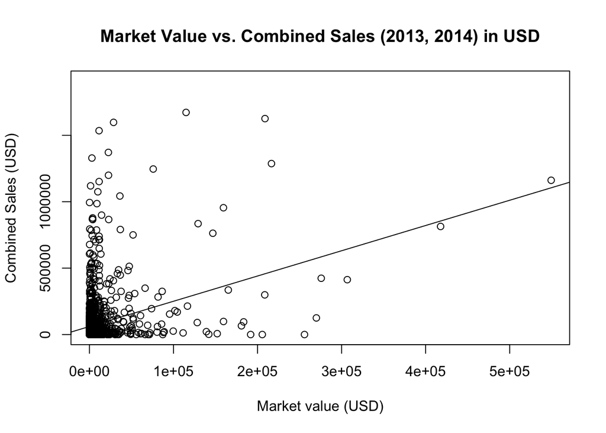

```r
plot(customer_accounts$market_value,
     customer_accounts$combined_sales,
     xlab="Market value (USD)",
     ylab="Combined Sales (USD)",
     main="Market Value vs. Combined Sales (2013, 2014) in USD")
modFit <- lm(combined_sales~market_value, data=customer_accounts)
abline(modFit)
```

There are many companies with high sales but low market value. The model’s low R-squared value indicates that much of the variance in sales is not due to market value alone, so we would need to consider other variables as well.

## 2.4: Does growth predict sales?

Do employee and revenue growth drive overall sales volume? The answer seems to be “no”. Established companies with low or no growth tend to account for greatest sales volume:

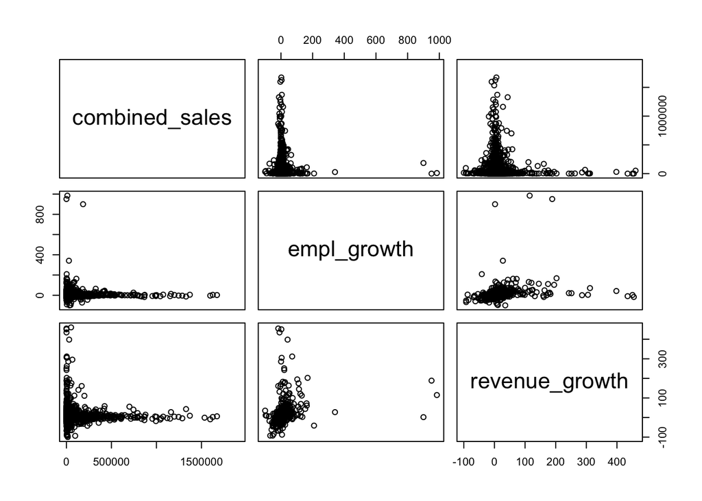

```r
pairs(~combined_sales + empl_growth + revenue_growth, data=customer_accounts)
```

There seems to be a slightly negative relationship between employee growth and sales, and between revenue growth and sales:

```r
modFit <- lm(combined_sales ~ empl_growth + revenue_growth, data=customer_accounts)
summary(modFit)
```

```
##
## Call:
## lm(formula = combined_sales ~ empl_growth + revenue_growth, data = customer_accounts)
##
## Residuals:
##     Min      1Q  Median      3Q     Max
## -108986  -75612  -58577   -4490 1589792
##
## Coefficients:
##                Estimate Std. Error t value Pr(>|t|)
## (Intercept)    84432.49    4842.24  17.437   <2e-16 ***
## empl_growth      -51.58      97.27  -0.530   0.5960
## revenue_growth  -271.19     126.44  -2.145   0.0321 *
## ---
## Signif. codes:  0 '***' 0.001 '**' 0.01 '*' 0.05 '.' 0.1 ' ' 1
##
## Residual standard error: 175700 on 1443 degrees of freedom
##   (42350 observations deleted due to missingness)
## Multiple R-squared:  0.004035,   Adjusted R-squared:  0.002654
## F-statistic: 2.923 on 2 and 1443 DF,  p-value: 0.0541
```

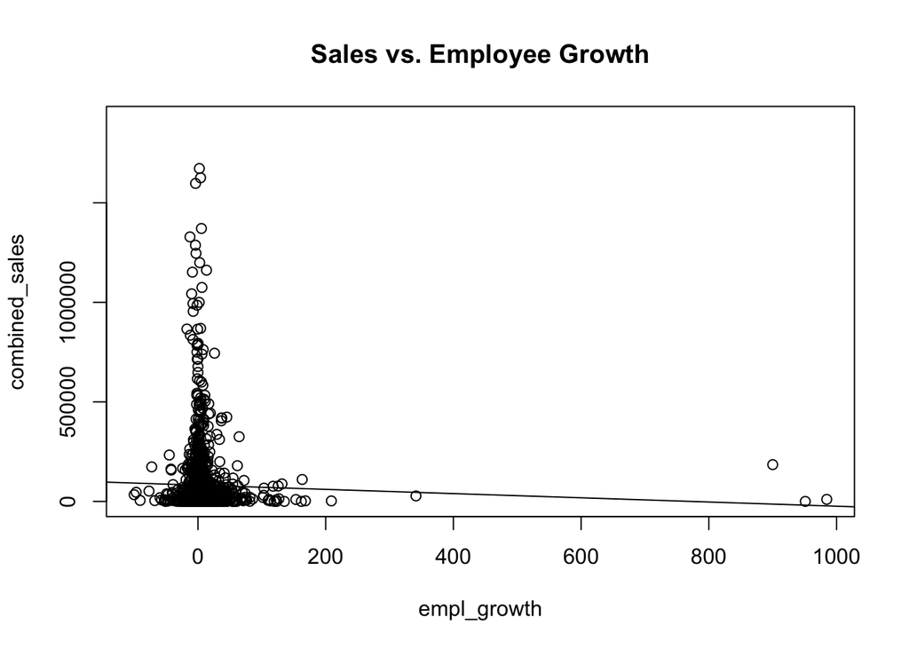

```r
plot(combined_sales ~ empl_growth, data=customer_accounts, main="Sales vs. Employee Growth")
abline(lm(combined_sales~empl_growth, data=customer_accounts))
```

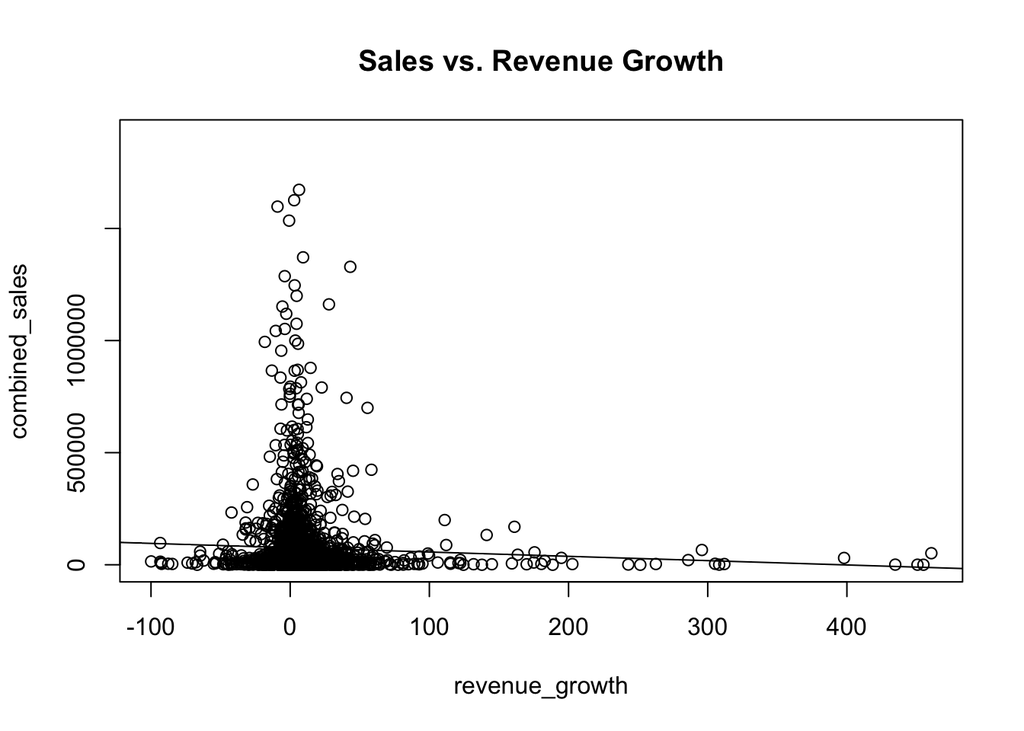

```r
plot(combined_sales ~ revenue_growth, data=customer_accounts, main="Sales vs. Revenue Growth")
abline(lm(combined_sales~revenue_growth, data=customer_accounts))
```

When we fit a regression model, we will see whether this relationship holds up in the context of other variables.

## 2.4: Top 10 Industries for Sales

```r
by_primary_industry <- group_by(customer_accounts, primary_industry)
sales_by_primary_industry <- summarize(by_primary_industry, sales=sum(combined_sales))
sales_by_primary_industry <- arrange(sales_by_primary_industry, desc(sales))
sales_by_primary_industry[1:10,c("primary_industry", "sales")]
```

```
## Source: local data frame [10 x 2]
##
##                                   primary_industry    sales
##                                             (fctr)    (dbl)
## 1                            Banks & Credit Unions 38880152
## 2                                 Wholesale Sector 34018687
## 3                                          Lending 21015514
## 4             Property/Casualty Insurance Carriers 19676198
## 5                 Industrial Equipment Wholesalers 19295948
## 6                                       Government 16698187
## 7  Steel Service Centers & Other Metal Wholesalers 16576819
## 8                  Information Technology Services 16256652
## 9                          Machinery Manufacturing 16063039
## 10                             Consulting Services 15867293
```

## 2.5: Top 10 Cities for Sales

```r
by_city <- group_by(customer_accounts, primary_city)
sales_by_city <- summarize(by_city, sales=sum(combined_sales))
sales_by_city <- arrange(sales_by_city, desc(sales))
sales_by_city[1:10,c("primary_city", "sales")]
```

```
## Source: local data frame [10 x 2]
##
##    primary_city    sales
##          (fctr)    (dbl)
## 1      New York 33657252
## 2       Houston 28313318
## 3       Chicago 18374783
## 4       Atlanta 14058292
## 5    Washington 11469350
## 6        Dallas 11312659
## 7  Philadelphia  8409997
## 8   Saint Louis  7139921
## 9     Cleveland  7064216
## 10       Boston  6650718
```

# Part 3: Modeling

## 3.1 Build Linear Regression model

We use stepwise linear regression to find a model that includes as many of the relevant variables needed to account for variance in combined sales. We start with the “null” model and step through additional predictors to find the best fit:

```r
# Stepwise Linear regression
library(MASS)
null <- lm(combined_sales ~ 1, data=na.omit(customer_accounts))
full <- lm(combined_sales ~ total_assets + market_value + net_income + revenue_growth + empl_growth + primary_industry + primary_city + is_manufacturing + is_minority_owned + db_pre_screen + is_importer + owns_rents + company_type + is_subsidiary + location_type + employees_at_this_location,
            data=na.omit(customer_accounts))
modFit <- step(null, scope=list(lower=null, upper=full), direction="forward")
```

```
## Start:  AIC=22736.68
## combined_sales ~ 1
##
##                               Df  Sum of Sq        RSS   AIC
## + market_value                 1 4.4276e+12 3.2161e+13 22618
## + net_income                   1 3.5188e+12 3.3070e+13 22644
## + total_assets                 1 1.4363e+12 3.5153e+13 22701
## + employees_at_this_location   1 7.2109e+11 3.5868e+13 22720
## + is_importer                  1 5.7766e+11 3.6011e+13 22724
## + is_manufacturing             1 2.9823e+11 3.6291e+13 22731
## + revenue_growth               1 2.5380e+11 3.6335e+13 22732
## + owns_rents                   2 3.2278e+11 3.6266e+13 22732
## <none>                                      3.6589e+13 22737
## + is_subsidiary                1 7.5360e+10 3.6513e+13 22737
## + empl_growth                  1 2.5096e+10 3.6564e+13 22738
## + is_minority_owned            1 7.0685e+09 3.6582e+13 22738
## + location_type                2 6.7974e+10 3.6521e+13 22739
## + db_pre_screen                3 1.2968e+11 3.6459e+13 22739
## + company_type                 3 3.3510e+10 3.6555e+13 22742
## + primary_industry           270 1.0845e+13 2.5744e+13 22949
## + primary_city               482 1.5683e+13 2.0906e+13 23179
##
## Step:  AIC=22618.47
## combined_sales ~ market_value
##
##                               Df  Sum of Sq        RSS   AIC
## + is_importer                  1 3.0820e+11 3.1853e+13 22612
## + total_assets                 1 2.4550e+11 3.1916e+13 22613
## + revenue_growth               1 2.1875e+11 3.1942e+13 22614
## + is_manufacturing             1 1.5542e+11 3.2006e+13 22616
## <none>                                      3.2161e+13 22618
## + is_subsidiary                1 5.3093e+10 3.2108e+13 22619
## + owns_rents                   2 8.0095e+10 3.2081e+13 22620
## + empl_growth                  1 9.6465e+09 3.2152e+13 22620
## + net_income                   1 8.3929e+09 3.2153e+13 22620
## + is_minority_owned            1 4.4309e+09 3.2157e+13 22620
## + employees_at_this_location   1 3.0473e+09 3.2158e+13 22620
## + location_type                2 3.9342e+10 3.2122e+13 22621
## + db_pre_screen                3 9.1134e+10 3.2070e+13 22622
## + company_type                 3 3.6744e+10 3.2124e+13 22623
```

[output cut: 45 more lines]

```
##
##                               Df  Sum of Sq        RSS   AIC
## <none>                                      3.1458e+13 22604
## + is_manufacturing             1 5.6266e+10 3.1402e+13 22604
## + is_subsidiary                1 4.6728e+10 3.1411e+13 22604
## + net_income                   1 1.1967e+10 3.1446e+13 22606
## + employees_at_this_location   1 7.1005e+09 3.1451e+13 22606
## + is_minority_owned            1 7.7873e+08 3.1457e+13 22606
## + empl_growth                  1 1.2698e+08 3.1458e+13 22606
## + owns_rents                   2 2.8923e+10 3.1429e+13 22607
## + location_type                2 2.7894e+10 3.1430e+13 22607
## + db_pre_screen                3 8.8360e+10 3.1370e+13 22607
## + company_type                 3 3.2735e+10 3.1425e+13 22609
## + primary_industry           270 1.0309e+13 2.1150e+13 22774
## + primary_city               482 1.3464e+13 1.7994e+13 23047
```

The output of step() shows the most important predictors are total_assets, market_value, revenue_growth and is_importer.

If we summarize the model, we see that total_assets, market_value and is_importer are positively related to sales, while revenue_growth is inversely related, as we conjectured in our exploratory analysis from Part 2.

```r
summary(modFit)
```

```
##
## Call:
## lm(formula = combined_sales ~ market_value + is_importer + total_assets +
##     revenue_growth, data = na.omit(customer_accounts))
##
## Residuals:
##     Min      1Q  Median      3Q     Max
## -668064  -76507  -47695    3856 1449811
##
## Coefficients:
##                  Estimate Std. Error t value Pr(>|t|)
## (Intercept)     6.109e+04  9.468e+03   6.452 1.77e-10 ***
## market_value    1.582e+00  1.673e-01   9.457  < 2e-16 ***
## is_importerYes  3.402e+04  1.223e+04   2.782  0.00551 **
## total_assets    9.979e-02  3.835e-02   2.602  0.00942 **
## revenue_growth -5.511e+02  2.680e+02  -2.056  0.04001 *
## ---
## Signif. codes:  0 '***' 0.001 '**' 0.01 '*' 0.05 '.' 0.1 ' ' 1
##
## Residual standard error: 184200 on 927 degrees of freedom
## Multiple R-squared:  0.1402, Adjusted R-squared:  0.1365
## F-statistic:  37.8 on 4 and 927 DF,  p-value: < 2.2e-16
```

## 3.2 Analyze Model Fit

Analaysis of Variance (Anova):

```r
modFit$anova
```

```
##               Step Df     Deviance Resid. Df   Resid. Dev      AIC
## 1                  NA           NA       931 3.658883e+13 22736.68
## 2   + market_value -1 4.427613e+12       930 3.216121e+13 22618.47
## 3    + is_importer -1 3.081975e+11       929 3.185302e+13 22611.49
## 4   + total_assets -1 2.513060e+11       928 3.160171e+13 22606.11
## 5 + revenue_growth -1 1.435190e+11       927 3.145819e+13 22603.87
```

Plots:

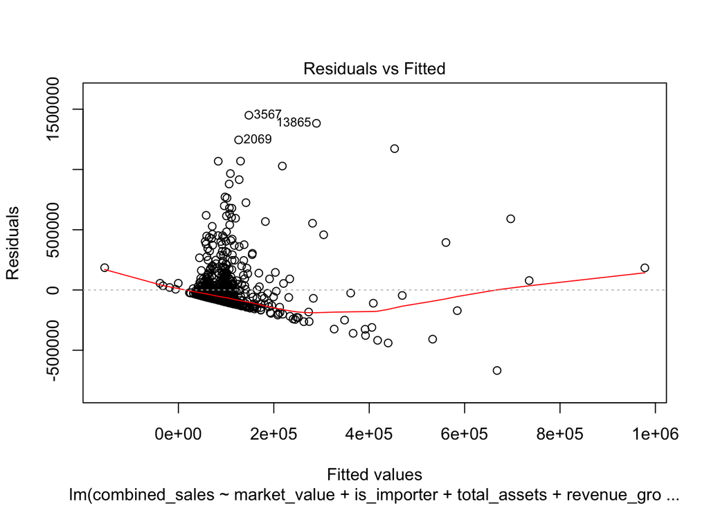

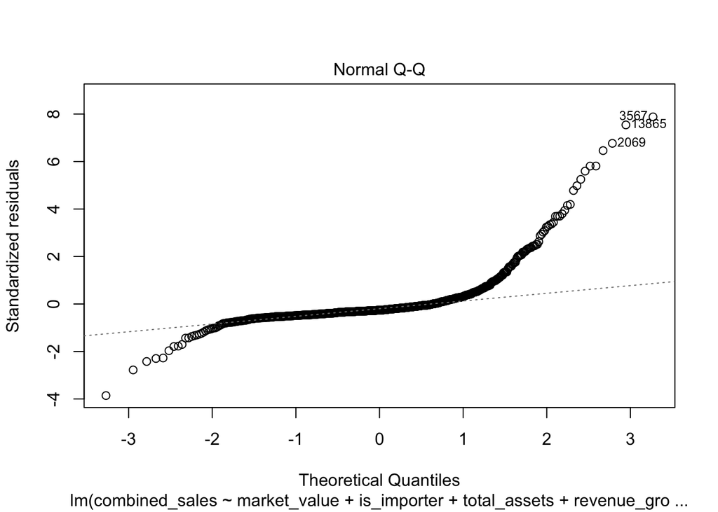

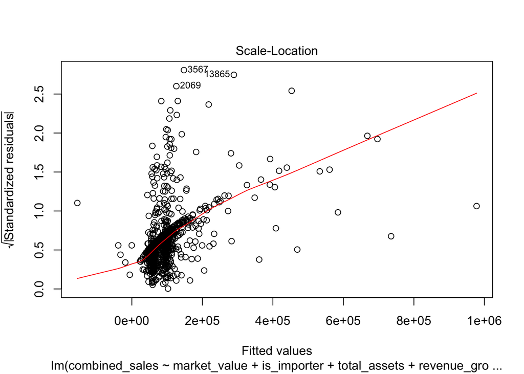

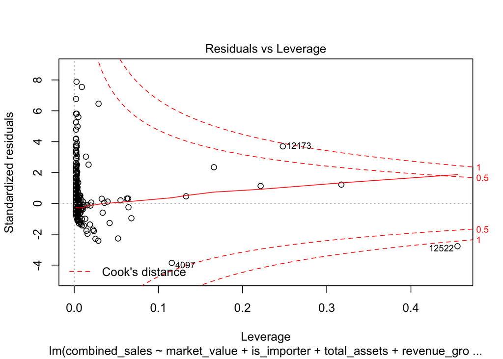

```r
plot(modFit)
```